# **Unsupervised Learning Project: AllLife Bank Customer Segmentation**

Welcome to the project on Unsupervised Learning. We will be using **Credit Card Customer Data** for this project.

## **Context**

**AllLife Bank wants to focus on its credit card customer base** in the next financial year. They have been advised by their marketing research team, that the penetration in the market can be improved. Based on this input, the marketing team proposes to run personalized campaigns to target new customers as well as upsell to existing customers.

Another insight from the market research was that the customers perceive the support services of the bank poorly. Based on this, the operations team wants to upgrade the service delivery model, to ensure that customers' queries are resolved faster. The head of marketing and the head of delivery, both decide to reach out to the Data Science team for help.

## **Objective**

**Identify different segments in the existing customer base**, taking into account their spending patterns as well as past interactions with the bank.

## **About the data**

Data is available on customers of the bank with their credit limit, the total number of credit cards the customer has, and different channels through which the customer has contacted the bank for any queries. These different channels include visiting the bank, online, and through a call center.

- **Sl_no** - Customer Serial Number
- **Customer Key** - Customer identification
- **Avg_Credit_Limit** - Average credit limit (currency is not specified, you can make an assumption around this)
- **Total_Credit_Cards** - Total number of credit cards
- **Total_visits_bank** - Total bank visits
- **Total_visits_online** - Total online visits
- **Total_calls_made** - Total calls made

## **Importing libraries and overview of the dataset**

**Note:** Please make sure you have installed the sklearn_extra library before running the below cell. If you have not installed the library, please run the below code to install the library:

!pip install scikit-learn-extra

```python
!pip install scikit-learn-extra
```

```python
import pandas as pd
import numpy as np
import matplotlib.pylab as plt
import seaborn as sns

from sklearn.preprocessing import StandardScaler

from sklearn.cluster import KMeans
from sklearn.mixture import GaussianMixture
import warnings
warnings.filterwarnings("ignore")
```

### **Loading the data**

```python
from google.colab import drive
drive.mount('/content/drive')
```

```python
data = pd.read_excel('/content/drive/MyDrive/MIT - Data Analytics/Elective Project/AllLife Bank/Credit Card Customer Data.xlsx')
```

### **Data Overview**

- Observations
- Sanity checks

```python
data.head()
```

|  | Sl_No | Customer Key | Avg_Credit_Limit | Total_Credit_Cards | Total_visits_bank | Total_visits_online | Total_calls_made |
| --- | --- | --- | --- | --- | --- | --- | --- |
| 0 | 1 | 87073 | 100000 | 2 | 1 | 1 | 0 |
| 1 | 2 | 38414 | 50000 | 3 | 0 | 10 | 9 |
| 2 | 3 | 17341 | 50000 | 7 | 1 | 3 | 4 |
| 3 | 4 | 40496 | 30000 | 5 | 1 | 1 | 4 |
| 4 | 5 | 47437 | 100000 | 6 | 0 | 12 | 3 |

```python
data.info()
```

```
<class 'pandas.core.frame.DataFrame'>
RangeIndex: 660 entries, 0 to 659
Data columns (total 7 columns):
 #   Column               Non-Null Count  Dtype
---  ------               --------------  -----
 0   Sl_No                660 non-null    int64
 1   Customer Key         660 non-null    int64
 2   Avg_Credit_Limit     660 non-null    int64
 3   Total_Credit_Cards   660 non-null    int64
 4   Total_visits_bank    660 non-null    int64
 5   Total_visits_online  660 non-null    int64
 6   Total_calls_made     660 non-null    int64
dtypes: int64(7)
memory usage: 36.2 KB
```

Observations:

- There are 660 entries and 7 columns in this data set
- All the columns are of integer data type
- None of the columns have any missing value

```python
data.nunique()
```

|  | 0 |
| --- | --- |
| Sl_No | 660 |
| Customer Key | 655 |
| Avg_Credit_Limit | 110 |
| Total_Credit_Cards | 10 |
| Total_visits_bank | 6 |
| Total_visits_online | 16 |
| Total_calls_made | 11 |

**dtype:** int64

- Customer Key seems to have duplicate values, this needs to be treated before anything is done.

```python
duplicate_keys = data['Customer Key'].duplicated(keep=False)

data[duplicate_keys]
```

|  | Sl_No | Customer Key | Avg_Credit_Limit | Total_Credit_Cards | Total_visits_bank | Total_visits_online | Total_calls_made |
| --- | --- | --- | --- | --- | --- | --- | --- |
| 4 | 5 | 47437 | 100000 | 6 | 0 | 12 | 3 |
| 48 | 49 | 37252 | 6000 | 4 | 0 | 2 | 8 |
| 104 | 105 | 97935 | 17000 | 2 | 1 | 2 | 10 |
| 332 | 333 | 47437 | 17000 | 7 | 3 | 1 | 0 |
| 391 | 392 | 96929 | 13000 | 4 | 5 | 0 | 0 |
| 398 | 399 | 96929 | 67000 | 6 | 2 | 2 | 2 |
| 411 | 412 | 50706 | 44000 | 4 | 5 | 0 | 2 |
| 432 | 433 | 37252 | 59000 | 6 | 2 | 1 | 2 |
| 541 | 542 | 50706 | 60000 | 7 | 5 | 2 | 2 |
| 632 | 633 | 97935 | 187000 | 7 | 1 | 7 | 0 |

```python
data = data.drop_duplicates(subset='Customer Key', keep=False)
```

```python
data.drop(columns = ['Sl_No', 'Customer Key'], inplace = True)
```

```python
data[data.duplicated()]
```

|  | Avg_Credit_Limit | Total_Credit_Cards | Total_visits_bank | Total_visits_online | Total_calls_made |
| --- | --- | --- | --- | --- | --- |
| 162 | 8000 | 2 | 0 | 3 | 4 |
| 175 | 6000 | 1 | 0 | 2 | 5 |
| 215 | 8000 | 4 | 0 | 4 | 7 |
| 295 | 10000 | 6 | 4 | 2 | 3 |
| 324 | 9000 | 4 | 5 | 0 | 4 |
| 361 | 18000 | 6 | 3 | 1 | 4 |
| 378 | 12000 | 6 | 5 | 2 | 1 |
| 385 | 8000 | 7 | 4 | 2 | 0 |
| 395 | 5000 | 4 | 5 | 0 | 1 |
| 455 | 47000 | 6 | 2 | 0 | 4 |
| 497 | 52000 | 4 | 2 | 1 | 2 |

```python
data = data[~data.duplicated()]
data.shape
```

```
(639, 5)
```

## **Data Preprocessing and Exploratory Data Analysis**

- EDA is an important part of any project involving data.
- It is important to investigate and understand the data better before building a model with it.
- A few questions have been mentioned below which will help you approach the analysis in the right manner and generate insights from the data.
- A thorough analysis of the data, in addition to the questions mentioned below, should be done.
- Check and drop the duplicate customer keys
- Drop the variables that are not required for the analysis
- Check duplicate rows and remove them.

**Questions:**

1. How does the distribution and outliers look for each variable in the data?
2. How are the variables correlated with each other?

#### **Check the summary Statistics**

```python
data.describe().T
```

|  | count | mean | std | min | 25% | 50% | 75% | max |
| --- | --- | --- | --- | --- | --- | --- | --- | --- |
| Avg_Credit_Limit | 639.0 | 34532.081377 | 37450.554493 | 3000.0 | 11000.0 | 18000.0 | 48000.0 | 200000.0 |
| Total_Credit_Cards | 639.0 | 4.699531 | 2.180100 | 1.0 | 3.0 | 5.0 | 6.0 | 10.0 |
| Total_visits_bank | 639.0 | 2.397496 | 1.620324 | 0.0 | 1.0 | 2.0 | 4.0 | 5.0 |
| Total_visits_online | 639.0 | 2.619718 | 2.942125 | 0.0 | 1.0 | 2.0 | 4.0 | 15.0 |
| Total_calls_made | 639.0 | 3.600939 | 2.870573 | 0.0 | 1.0 | 3.0 | 5.0 | 10.0 |

#### **Scaling the data**

```
Avg_Credit_Limit
Skew : 2.2
```

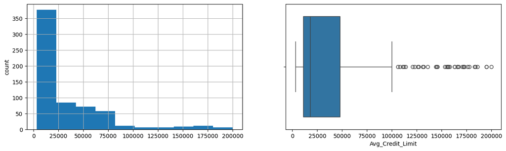

```
Total_Credit_Cards
Skew : 0.16
```

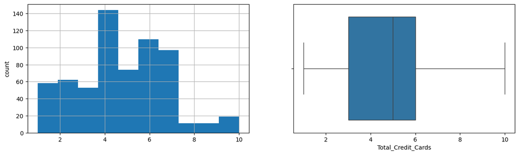

```
Total_visits_bank
Skew : 0.15
```

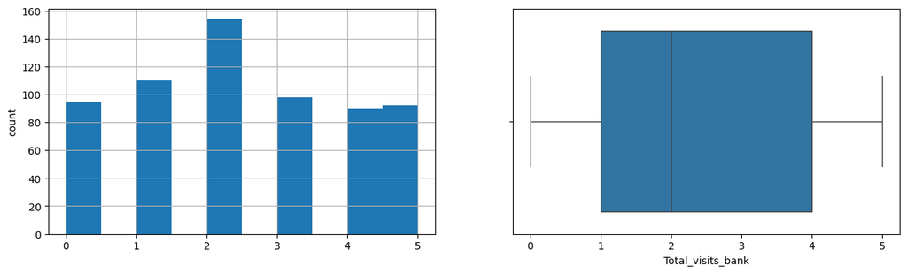

```
Total_visits_online
Skew : 2.22
```

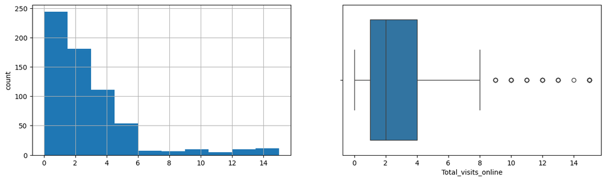

```
Total_calls_made
Skew : 0.65
```

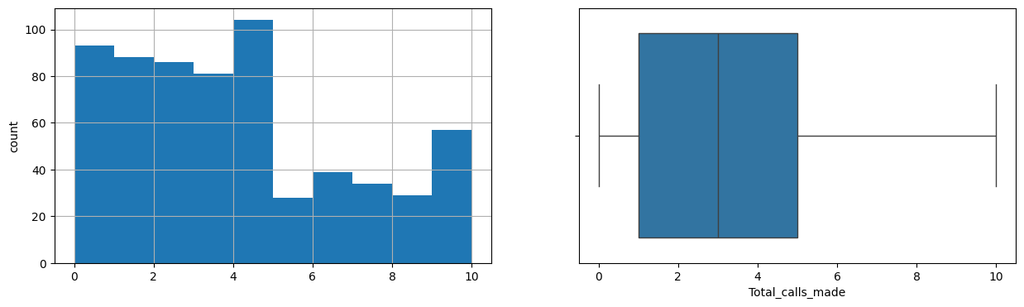

```python
for col in data.columns:
    print(col)
    print('Skew :', round(data[col].skew(), 2))

    plt.figure(figsize = (15, 4))
    plt.subplot(1, 2, 1)

    data[col].hist()

    plt.ylabel('count')

    plt.subplot(1, 2, 2)

    sns.boxplot(x = data[col])

    plt.show()
```

Average credit limit

Total Credit cards

- Most people have 4 credit cards and on average they seem to have 5.
- Boxplot has no outliers which measn it is a good distribution

Total Visits bank

- There is a peak at 2 visits with most people going twice.
- It seems like a normal distribution with it being fairly balanced.
- There are no outliers.

Total visits online

Total calls made

- the distribution is fairly uniform with the peak at 4-5 calls
- The average number of calls seems to be 3

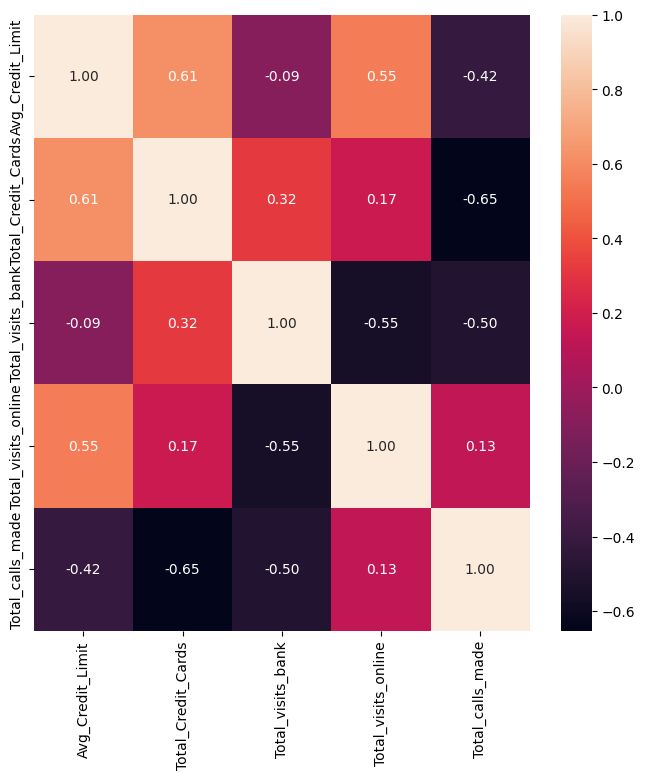

```python
plt.figure(figsize = (8, 8))

sns.heatmap(data.corr(), annot = True, fmt = '0.2f')

plt.show()
```

- The average credit limit is negatively correlated with total calls made and total visits bank.
- The average credit limit is positively correlated with total credit cards and total visitis online.

#### **Applying PCA on scaled data**

```python
scaler = StandardScaler()
data_scaled = StandardScaler().fit_transform(data)
```

```python
from sklearn.decomposition import PCA

n = data.shape[1]

pca = PCA(n_components=n)

principal_components = pca.fit_transform(data_scaled)

data_pca = pd.DataFrame(principal_components, columns = data.columns)
```

```python
data_copy = data_pca.copy(deep = True)
```

## **K-Means**

Let us now fit the K-means algorithm on our pca components and find out the optimum number of clusters to use.

We will do this in 3 steps:

1. Initialize a dictionary to store the Sum of Squared Error (SSE) for each K
2. Run for a range of Ks and store SSE for each run
3. Plot the SSE vs K and plot the elbow curve

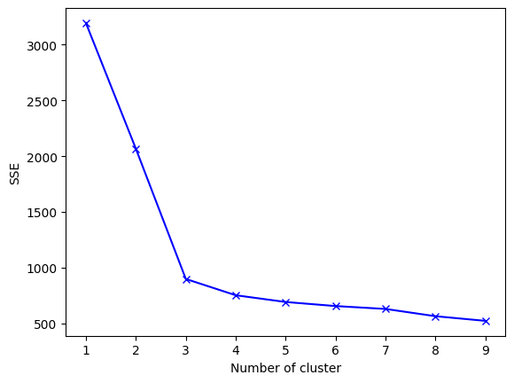

```python
#1
sse = {}

# 2
for k in range(1, 10):
    kmeans = KMeans(n_clusters = k, max_iter = 1000, random_state = 1).fit(data_pca)
    sse[k] = kmeans.inertia_

# 3
plt.figure()
plt.plot(list(sse.keys()), list(sse.values()), 'bx-')
plt.xlabel("Number of cluster")
plt.ylabel("SSE")

plt.show()
```

- Interpret the above elbow plot and state the reason for choosing the particular value of K
- Fit the K-means algorithms on the pca components with the number of clusters for the chosen value of K

The chosen value of K is 3. The reason is as this is the elbow point where the curve bends and the reduction becomes smaller. This avoids overfitting the data while still capturing the structure of the data.

```python
kmeans = KMeans(n_clusters=3, max_iter=1000, random_state=1)

kmeans.fit(data_pca)

data_copy['Labels'] = kmeans.labels_
data['Labels'] = kmeans.labels_
```

#### **Create the cluster profiles using the summary statistics and box plots for each label**

```python
data.Labels.value_counts()
```

| Labels | count |
| --- | --- |
| 0 | 372 |
| 2 | 219 |
| 1 | 48 |

**dtype:** int64

```python
mean = data.groupby('Labels').mean()
median = data.groupby('Labels').median()

df_kmeans = pd.concat([mean, median], axis = 0)
df_kmeans.index = ['group_0 Mean', 'group_1 Mean', 'group_2 Mean', 'group_0 Median', 'group_1 Median', 'group_2 Median']
df_kmeans.T
```

|  | group_0 Mean | group_1 Mean | group_2 Mean | group_0 Median | group_1 Median | group_2 Median |
| --- | --- | --- | --- | --- | --- | --- |
| Avg_Credit_Limit | 33922.043011 | 140937.500000 | 12246.575342 | 31500.0 | 145500.0 | 12000.0 |
| Total_Credit_Cards | 5.516129 | 8.833333 | 2.406393 | 6.0 | 9.0 | 2.0 |
| Total_visits_bank | 3.481183 | 0.604167 | 0.949772 | 3.0 | 1.0 | 1.0 |
| Total_visits_online | 0.981183 | 10.958333 | 3.575342 | 1.0 | 11.0 | 4.0 |
| Total_calls_made | 2.002688 | 1.062500 | 6.872146 | 2.0 | 1.0 | 7.0 |

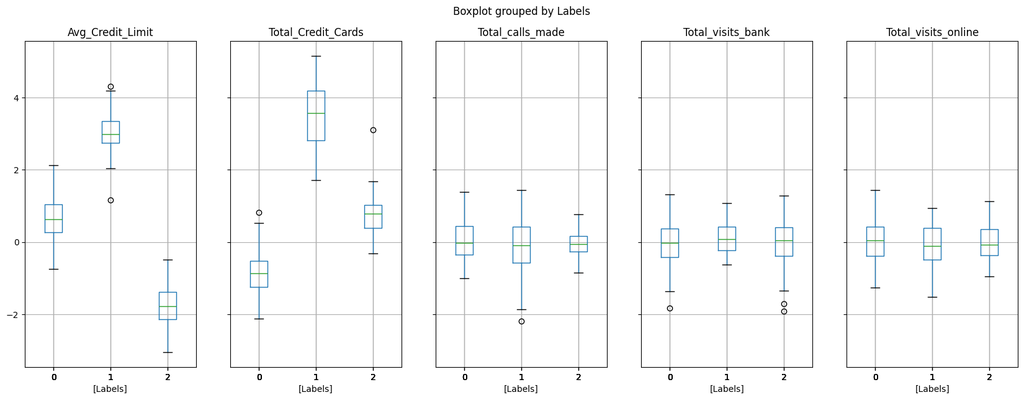

```python
data_copy.boxplot(by = 'Labels', layout = (1, 5), figsize = (20, 7))

plt.show()
```

**Cluster Profiles:_______________**

Cluster 0

- Average Credit Limit: Moderate. mean at 33,920
- Total Credit Cards: Moderate, mean at 5.5
- Total Visits Bank: High, mean at 3.4
- Total Visits Online: Low, mean at 0.98
- Total Calls Made: Moderate, mean at 2

Cluster 1

- Average Credit Limit: High, mean at 140,937
- Total Credit Cards: High, mean at 8.8
- Total Visits Bank: Low, mean at 0.6
- Total Visits Online: High, mean at 10.9
- Total Calls Made: Low, mean at 1.06

- Average Credit Limit: Low, mean at 12,246
- Total Credit Cards: Low, mean at 2.4
- Total Visits Bank: Moderate, mean at 0.9
- Total Visits Online: Moderate, mean at 3.6
- Total Calls Made: High, mean at 6.9

## **Gaussian Mixture Model**

Let's now create clusters using the Gaussian Mixture Model.

- Apply the Gaussian Mixture Model algorithm on the pca components

```python
gmm = GaussianMixture(n_components=3, random_state=1)

gmm.fit(data_pca)

data_copy['GmmLabels'] = gmm.predict(data_pca)
data['GmmLabels'] = gmm.predict(data_pca)
```

```python
data.GmmLabels.value_counts()
```

| GmmLabels | count |
| --- | --- |
| 0 | 372 |
| 2 | 219 |
| 1 | 48 |

**dtype:** int64

#### **Create the cluster profiles using the summary statistics and box plots for each label**

```python
original_features = ["Avg_Credit_Limit", "Total_Credit_Cards", "Total_visits_bank", "Total_visits_online", "Total_calls_made"]

mean = data.groupby('GmmLabels').mean()
median = data.groupby('GmmLabels').median()

df_gmm = pd.concat([mean, median], axis = 0)
df_gmm.index = ['group_0 Mean', 'group_1 Mean', 'group_2 Mean', 'group_0 Median', 'group_1 Median', 'group_2 Median']
df_gmm[original_features].T
```

|  | group_0 Mean | group_1 Mean | group_2 Mean | group_0 Median | group_1 Median | group_2 Median |
| --- | --- | --- | --- | --- | --- | --- |
| Avg_Credit_Limit | 33922.043011 | 140937.500000 | 12246.575342 | 31500.0 | 145500.0 | 12000.0 |
| Total_Credit_Cards | 5.516129 | 8.833333 | 2.406393 | 6.0 | 9.0 | 2.0 |
| Total_visits_bank | 3.481183 | 0.604167 | 0.949772 | 3.0 | 1.0 | 1.0 |
| Total_visits_online | 0.981183 | 10.958333 | 3.575342 | 1.0 | 11.0 | 4.0 |
| Total_calls_made | 2.002688 | 1.062500 | 6.872146 | 2.0 | 1.0 | 7.0 |

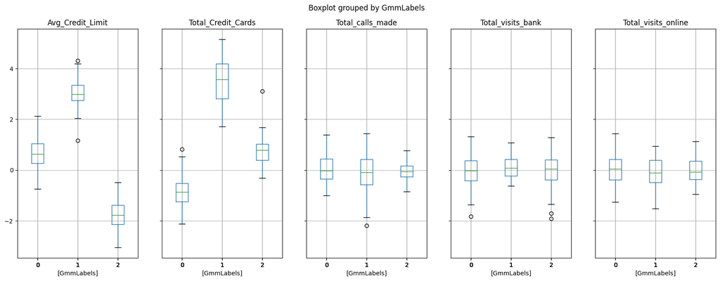

```python
features_with_lables = ["Avg_Credit_Limit", "Total_Credit_Cards", "Total_visits_bank", "Total_visits_online", "Total_calls_made", "GmmLabels"]

data_copy[features_with_lables].boxplot(by = 'GmmLabels', layout = (1, 5),figsize = (20, 7))

plt.show()
```

#### **Compare the clusters from both algorithms - K-means and Gaussian Mixture Model**

```python
(data['Labels'] == data['GmmLabels']).value_counts()
```

|  | count |
| --- | --- |
| True | 639 |

**dtype:** int64

**Comparing Clusters:____________**

As visible from both the clusters K-Means and GMM produced identical cluster assignments for every customer in this dataset. Which means there is no need to distinguish between the two models for interpretations.

## **K-Medoids**

- Apply the K-Medoids clustering algorithm on the pca components

```python
!pip install scikit-learn-extra
```

```python
from sklearn_extra.cluster import KMedoids

kmedo = KMedoids(n_clusters=3, random_state=1)
kmedo.fit(data_pca)

data_copy['kmedoLabels'] = kmedo.predict(data_pca)

data['kmedoLabels'] = kmedo.predict(data_pca)
```

```python
data.kmedoLabels.value_counts()
```

| kmedoLabels | count |
| --- | --- |
| 2 | 287 |
| 0 | 220 |
| 1 | 132 |

**dtype:** int64

#### **Create cluster profiles using the summary statistics and box plots for each label**

```python
mean = data.groupby('kmedoLabels').mean()

median = data.groupby('kmedoLabels').median()

df_kmedoids = pd.concat([mean, median], axis = 0)

df_kmedoids.index = ['group_0 Mean', 'group_1 Mean', 'group_2 Mean', 'group_0 Median', 'group_1 Median', 'group_2 Median']

df_kmedoids[original_features].T
```

|  | group_0 Mean | group_1 Mean | group_2 Mean | group_0 Median | group_1 Median | group_2 Median |
| --- | --- | --- | --- | --- | --- | --- |
| Avg_Credit_Limit | 12222.727273 | 84939.393939 | 28449.477352 | 12000.0 | 68000.0 | 20000.0 |
| Total_Credit_Cards | 2.418182 | 7.037879 | 5.372822 | 2.0 | 7.0 | 5.0 |
| Total_visits_bank | 0.954545 | 1.704545 | 3.822300 | 1.0 | 2.0 | 4.0 |
| Total_visits_online | 3.568182 | 4.583333 | 0.989547 | 4.0 | 2.0 | 1.0 |
| Total_calls_made | 6.859091 | 1.962121 | 1.857143 | 7.0 | 2.0 | 2.0 |

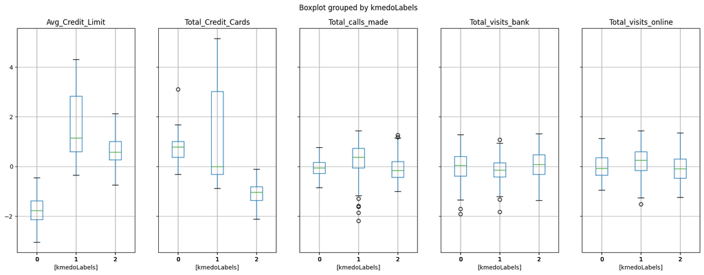

```python
features_with_lables = ["Avg_Credit_Limit", "Total_Credit_Cards", "Total_visits_bank", "Total_visits_online", "Total_calls_made", "kmedoLabels"]

data_copy[features_with_lables].boxplot(by = 'kmedoLabels', layout = (1, 5), figsize = (20, 7))

plt.show()
```

**Cluster Profiles:____________**

Cluster 0

- Average Credit Limit: Low. mean at 12,222
- Total Credit Cards: Low mean at 2.4
- Total Visits Bank: Low, mean at 0.95
- Total Visits Online: Moderate, mean at 3.6
- Total Calls Made: High, mean at 6.9

Cluster 1

- Average Credit Limit: High, mean at 84,939
- Total Credit Cards: High, mean at 7
- Total Visits Bank: Moderate, mean at 1.7
- Total Visits Online: High, mean at 4.6
- Total Calls Made: Moderate, mean at 1.96

This group of customers are high value customers, they requre a lot of maintanence as well.

- Average Credit Limit: Moderate, mean at 28,449
- Total Credit Cards: Moderate, mean at 5.4
- Total Visits Bank: High, mean at 3.8
- Total Visits Online: Low, mean at 1.0
- Total Calls Made: Low, mean at 1.86

These are balanced users. They have moderate credit and engagement. They may represent the average or transitional segment between the other two clusters.

#### **Compare the clusters from K-Means and K-Medoids**

```python
comparison = pd.concat([df_kmedoids, df_kmeans], axis = 1)[original_features]

comparison
```

|  | Avg_Credit_Limit | Avg_Credit_Limit | Total_Credit_Cards | Total_Credit_Cards | Total_visits_bank | Total_visits_bank | Total_visits_online | Total_visits_online | Total_calls_made | Total_calls_made |
| --- | --- | --- | --- | --- | --- | --- | --- | --- | --- | --- |
| group_0 Mean | 12222.727273 | 33922.043011 | 2.418182 | 5.516129 | 0.954545 | 3.481183 | 3.568182 | 0.981183 | 6.859091 | 2.002688 |
| group_1 Mean | 84939.393939 | 140937.500000 | 7.037879 | 8.833333 | 1.704545 | 0.604167 | 4.583333 | 10.958333 | 1.962121 | 1.062500 |
| group_2 Mean | 28449.477352 | 12246.575342 | 5.372822 | 2.406393 | 3.822300 | 0.949772 | 0.989547 | 3.575342 | 1.857143 | 6.872146 |
| group_0 Median | 12000.000000 | 31500.000000 | 2.000000 | 6.000000 | 1.000000 | 3.000000 | 4.000000 | 1.000000 | 7.000000 | 2.000000 |
| group_1 Median | 68000.000000 | 145500.000000 | 7.000000 | 9.000000 | 2.000000 | 1.000000 | 2.000000 | 11.000000 | 2.000000 | 1.000000 |
| group_2 Median | 20000.000000 | 12000.000000 | 5.000000 | 2.000000 | 4.000000 | 1.000000 | 1.000000 | 4.000000 | 2.000000 | 7.000000 |

**Comparing Clusters:___________________**

Cluster 0:

- K Medoids captures this group as low credit, high service need whereas K Means captures this group as mid credit, branch first users.

Cluster 1:

## **Conclusions and Business Recommendations**

- It is important for the business to penetrate the credit card segent further. They need to launch personalized marketing campaigns based on the clusters defined.
- A lot of customers seem to be visiting the branch multiple times or online so therefore it is important to increase customer support experience.
- Cluster 0 are the low average credit limit and high engagement customers. They are probably younger people. For them the bank can promote self service tools, provide them with ways to boost their credit limits.
- Cluster 1 are the affluent speakers. They have very high credit limit and low engagement. This means they are wealthy class. For them the bank can create VIP loyalty program, offer more cashback, offer lifestyle perks.
- Cluster 2 are the mid range credit limit customers with very low digital engagement. For them the bank can create online registration programs, provide additional benefit if done online, have more webinars in place to help them with digital adoption.